# Cyclistic Case Study Report

Ayoub

2025-11-17

# ASK

**Business Task**  
Analyze how annual members and casual riders use Cyclistic bikes differently to help design a marketing strategy that converts casual riders into annual members.

# PREPARE

**Data Source**  
- Divvy 2019 Q1  
- Divvy 2020 Q1  
- Public dataset made available by Motivate International Inc.  
- No PII included

# PROCESS

```r
# Load raw data
q1_2019 <- read_csv("Data_raw/Divvy_Trips_2019_Q1.csv")
q1_2020 <- read_csv("Data_raw/Divvy_Trips_2020_Q1.csv")

# Clean column names
q1_2019 <- clean_names(q1_2019)
q1_2020 <- clean_names(q1_2020)

# Standardize 2019 schema:
# - trip_id as character
# - create member_casual from usertype (Subscriber = member, Customer = casual)
# - parse started_at / ended_at from start_time / end_time
q1_2019 <- q1_2019 %>%
  mutate(
    trip_id       = as.character(trip_id),
    member_casual = if_else(usertype == "Subscriber", "member", "casual"),
    started_at    = ymd_hms(start_time),
    ended_at      = ymd_hms(end_time)
  )

# Standardize 2020 schema:
# - trip_id from ride_id
# - make sure started_at / ended_at are parsed
q1_2020 <- q1_2020 %>%
  mutate(
    trip_id    = as.character(ride_id),
    started_at = ymd_hms(started_at),
    ended_at   = ymd_hms(ended_at)
  )

# Keep only common / needed columns and stack them
all_trips <- bind_rows(
  q1_2019 %>% select(trip_id, started_at, ended_at, member_casual),
  q1_2020 %>% select(trip_id, started_at, ended_at, member_casual)
)

# Create time-based variables & ride length
all_trips <- all_trips %>%
  mutate(
    ride_length = as.numeric(difftime(ended_at, started_at, units = "mins")),
    day_of_week = wday(started_at, label = TRUE),
    month       = month(started_at, label = TRUE),
    hour        = hour(started_at)
  )

# Remove invalid rides
all_trips_clean <- all_trips %>%
  filter(
    !is.na(ride_length),
    ride_length > 0,
    ride_length < 1440
  )

glimpse(all_trips_clean)
```

```
## Rows: 791,264
## Columns: 8
## $ trip_id       <chr> "21742443", "21742444", "21742445", "21742446", "2174244…
## $ started_at    <dttm> 2019-01-01 00:04:37, 2019-01-01 00:08:13, 2019-01-01 00…
## $ ended_at      <dttm> 2019-01-01 00:11:07, 2019-01-01 00:15:34, 2019-01-01 00…
## $ member_casual <chr> "member", "member", "member", "member", "member", "membe…
## $ ride_length   <dbl> 6.500000, 7.350000, 13.816667, 29.716667, 6.066667, 3.60…
## $ day_of_week   <ord> Tue, Tue, Tue, Tue, Tue, Tue, Tue, Tue, Tue, Tue, Tue, T…
## $ month         <ord> Jan, Jan, Jan, Jan, Jan, Jan, Jan, Jan, Jan, Jan, Jan, J…
## $ hour          <int> 0, 0, 0, 0, 0, 0, 0, 0, 0, 0, 0, 0, 0, 0, 0, 0, 0, 0, 0,…
```

# ANALYZE

## Ride length by rider type

```r
all_trips_clean %>%
  group_by(member_casual) %>%
  summarise(
    mean_ride_length   = mean(ride_length),
    median_ride_length = median(ride_length),
    max_ride_length    = max(ride_length)
  )
```

```
## # A tibble: 2 × 4
##   member_casual mean_ride_length median_ride_length max_ride_length
##   <chr>                    <dbl>              <dbl>           <dbl>
## 1 casual                    36.5              22.0            1436.
## 2 member                    11.4               8.47           1433.
```

## Rides by day of week

```r
all_trips_clean %>%
  group_by(member_casual, day_of_week) %>%
  summarise(num_rides = n(), .groups = "drop")
```

```
## # A tibble: 14 × 3
##    member_casual day_of_week num_rides
##    <chr>         <ord>           <int>
##  1 casual        Sun             18578
##  2 casual        Mon              6672
##  3 casual        Tue              7949
##  4 casual        Wed              8328
##  5 casual        Thu              7729
##  6 casual        Fri              8466
##  7 casual        Sat             13416
##  8 member        Sun             60178
##  9 member        Mon            110412
## 10 member        Tue            127946
## 11 member        Wed            121879
## 12 member        Thu            125198
## 13 member        Fri            115132
## 14 member        Sat             59381
```

## Rides by hour of day

```r
all_trips_clean %>%
  group_by(member_casual, hour) %>%
  summarise(num_rides = n(), .groups = "drop")
```

```
## # A tibble: 48 × 3
##    member_casual  hour num_rides
##    <chr>         <int>     <int>
##  1 casual            0       460
##  2 casual            1       328
##  3 casual            2       240
##  4 casual            3       143
##  5 casual            4        91
##  6 casual            5       194
##  7 casual            6       482
##  8 casual            7      1043
##  9 casual            8      1996
## 10 casual            9      2578
## # ℹ 38 more rows
```

# VISUALIZATIONS

## Average Ride Length: Members vs Casual Riders

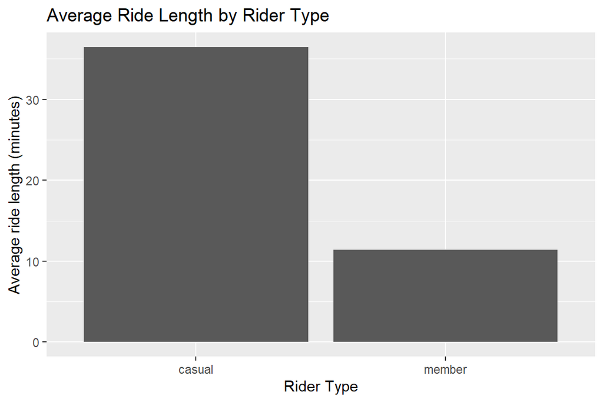

```r
all_trips_clean %>%
  group_by(member_casual) %>%
  summarise(mean_ride_length = mean(ride_length)) %>%
  ggplot(aes(x = member_casual, y = mean_ride_length)) +
  geom_col() +
  labs(
    x = "Rider Type",
    y = "Average ride length (minutes)",
    title = "Average Ride Length by Rider Type"
  )
```

## Number of Rides by Day of Week

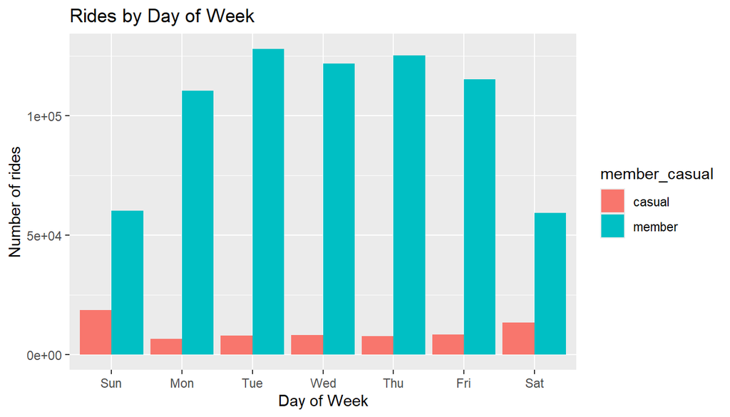

```r
all_trips_clean %>%
  count(member_casual, day_of_week) %>%
  ggplot(aes(x = day_of_week, y = n, fill = member_casual)) +
  geom_col(position = "dodge") +
  labs(
    x = "Day of Week",
    y = "Number of rides",
    title = "Rides by Day of Week"
  )
```

## Number of Rides by Hour of Day

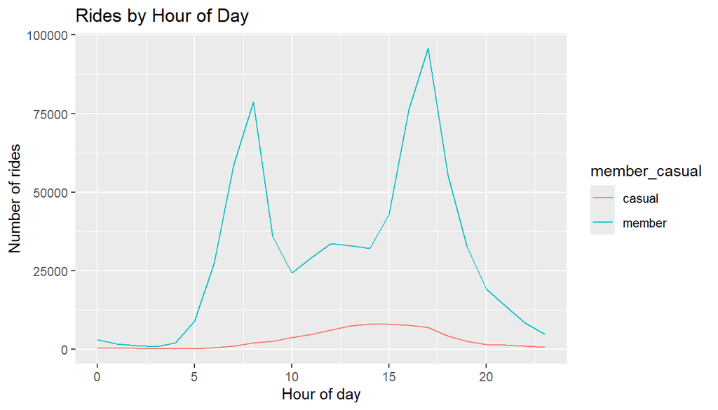

```r
all_trips_clean %>%
  count(member_casual, hour) %>%
  ggplot(aes(x = hour, y = n, color = member_casual)) +
  geom_line() +
  labs(
    x = "Hour of day",
    y = "Number of rides",
    title = "Rides by Hour of Day"
  )
```

# SHARE: Key Findings

**Segments:**  
- **Members = commuters**  
- **Casual = leisure/occasional riders**

# ACT: Recommendations

### 2. Commuter-Focused Campaigns

- Emphasize **time/money savings**.
- Partner with employers for **corporate discounts**.

### 3. Digital Behavioral Targeting

- Show in-app prompts after long rides.
- Use weekend social media ads toward leisure riders.

# Conclusion

Cyclistic can grow revenue by **converting casual riders into annual members**.  
Behavior-based marketing—using ride length, timing, and seasonality—allows targeted campaigns that match actual rider behavior.